# Practical Machine Learning: Weightlifting Prediction Exercise

Shivam Giri

September 17, 2017

## Overview

Using devices such as Jawbone Up, Nike FuelBand, and Fitbit it is now possible to collect a large amount of data about personal activity relatively inexpensively.In this project, Our goal will be to use data from accelerometers on the belt, forearm, arm, and dumbell of 6 participants and to predict the manner in which they did the exercise. More information is available from the website (http://groupware.les.inf.puc-rio.br/har)

## Loading the Data

```r
train_raw<-read.csv("F:/Downloads/pml-training.csv",header = TRUE)
validation<-read.csv("F:/Downloads/pml-testing.csv",header = TRUE)
```

## Cleaning the Data

```r
#Some coloumn contains NAs in excess
maxNA_perc<-20
maxNA_count<-nrow(train_raw)/100*maxNA_perc

#Insignificant Columns(NAs) & time series columns
insig_column<-which(colSums(is.na(train_raw)|train_raw=="")>maxNA_count)
ts_col<-grep("timestamp",names(train_raw))

#Removing Time series Columns and insignificant columns
train_cleaned<-train_raw[,-c(1,ts_col,insig_column)]
validation_cleaned<-validation[,-c(1,ts_col,insig_column)]
```

## Data Slicing

```r
library(caret)
```

```r
library(ggplot2)
library(lattice)
set.seed(2334)
inTrain<-createDataPartition(train_cleaned$classe,p=.7,list = FALSE)
training<-train_cleaned[inTrain,]
testing<-train_cleaned[-inTrain,]
```

## Exploratory data analysis

```r
dim(training)
dim(testing)
str(training)
str(testing)
```

[output not shown]

## Model Selection

For this project I’ll use 3 differnt model algorithms and then look to see which provides the best out-of-sample accuracty. The three model types I’m going to test are:

1)Decision trees with CART (rpart) 2)Stochastic gradient boosting trees (gbm) 3)Random forest decision trees (rf)

```r
library(survival)
model_rpart<-train(classe~.,data = training,method="rpart")
model_gbm<-train(classe~.,data = training,method="gbm",verbose=FALSE)
model_rf<-train(classe~.,data = training,method="rf")
```

### CART(rpart) model

```r
library(rattle)
```

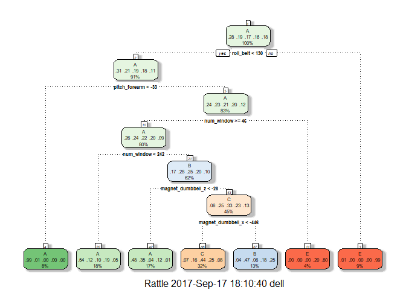

```r
fancyRpartPlot(model_rpart$finalModel)
```

## Model Assessment

```r
#Predictions on testing dataset
pred_rpart<-predict(model_rpart,newdata = testing)
pred_gbm<-predict(model_gbm,newdata = testing)
pred_rf<-predict(model_rf,newdata = testing)

#Confusion matrix(Accuracy) of different models
cm_rpart<-confusionMatrix(testing$classe,pred_rpart)$overall
cm_gbm<-confusionMatrix(testing$classe,pred_gbm)$overall
cm_rf<-confusionMatrix(testing$classe,pred_rf)$overall
data.frame(Model=c("Cart","gbm","rf"),Accuracy=c(cm_rpart[1],cm_gbm[1],cm_rf[1]))
```

```
##   Model  Accuracy
## 1  Cart 0.5559898
## 2   gbm 0.9860663
## 3    rf 0.9983008
```

The next step should be to create an ensemble model, but given the very high accuracy of ‘rf models, we will adopt ’rf’ model as the final model.

# Prediction

Performing prediction on validation dataset as the final step to evaluate the model

```r
pred_valid<-predict(model_rf,newdata = validation_cleaned)
final_pred<-data.frame("Problem_id"=validation_cleaned$problem_id,"Predicted Value"=pred_valid)
print(final_pred)
```

```
##    Problem_id Predicted.Value
## 1           1               B
## 2           2               A
## 3           3               B
## 4           4               A
## 5           5               A
## 6           6               E
## 7           7               D
## 8           8               B
## 9           9               A
## 10         10               A
## 11         11               B
## 12         12               C
## 13         13               B
## 14         14               A
## 15         15               E
## 16         16               E
## 17         17               A
## 18         18               B
## 19         19               B
## 20         20               B
```